Social Utility Modeling

# Tutorial 4 - Li et al., 2022

## 1.4 Model the Data Generation Process

First, let's define the functions

```python
import numpy as np
import pandas as pd

def inequality(a1, b1, a2, b2):
    d_Inequality = abs(a2 - b2) - abs(a1 - b1)
    return d_Inequality

def harm(a0, b0, a1, b1, a2, b2):
    initial = np.array([a0, b0])
    choice1 = np.array([a1, b1])
    choice2 = np.array([a2, b2])
    advantaged = 1 if a0 == b0 else np.argmax(initial)
    d_lossAdvantaged = (initial[advantaged] - choice1[advantaged]) - (initial[advantaged] - choice2[advantaged])
    return d_lossAdvantaged

def rankReverse(a0, b0, a1, b1, a2, b2):
    if a0 == b0:
        return 0
    d_initial = a0 - b0
    d_choice1 = a1 - b1
    d_choice2 = a2 - b2
    if d_initial > 0:
        choice1Reversed = 1 if d_choice1 < 0 else 0
        choice2Reversed = 1 if d_choice2 < 0 else 0
    else:
        choice1Reversed = 1 if d_choice1 > 0 else 0
        choice2Reversed = 1 if d_choice2 > 0 else 0
    return choice1Reversed - choice2Reversed
```

Now let's check and see if they do what we want. Let's make an example trial for two players A and B with starting allocations a0 and b0 and possible choices 1 and 2 with different distributions between player A and player B:

```python
example = pd.DataFrame({'a0': [20], 'b0': [0], 'a1': [8], 'b1': [12], 'a2': [15], 'b2': [5]})
example
```

|  | a0 | b0 | a1 | b1 | a2 | b2 |
| --- | --- | --- | --- | --- | --- | --- |
| 0 | 20 | 0 | 8 | 12 | 15 | 5 |

Now we can view the outputs of this example to make sure they look correct:

```python
print(inequality(example['a1'][0], example['b1'][0], example['a2'][0], example['b2'][0]))
print(harm(example['a0'][0], example['b0'][0], example['a1'][0], example['b1'][0], example['a2'][0], example['b2'][0]))
print(rankReverse(example['a0'][0], example['b0'][0], example['a1'][0], example['b1'][0], example['a2'][0], example['b2'][0]))
```

```
6
7
1
```

So choice 1 is 6 more equal, causes more 7 harm, and reverses the existing rank. This is correct!

## 1.5 Simulating Data

Now let's preallocate and define functions, triallist, and parameters

```python
trialList = pd.DataFrame({
    'a0': np.random.randint(10, 21, 100)
})
trialList['b0'] = 20 - trialList['a0']
trialList['a1'] = [np.random.randint(5, a0 + 1) for a0 in trialList['a0']]
trialList['b1'] = 20 - trialList['a1']
trialList['a2'] = [np.random.randint(5, a0 + 1) for a0 in trialList['a0']]
trialList.loc[trialList['a2'] == trialList['a1'], ('a2')] = 10
trialList['b2'] = 20 - trialList['a2']
trialList = pd.concat([trialList, trialList[['b0', 'a0', 'b1', 'a1', 'b2', 'a2']]], ignore_index=True)

trialList
```

|  | a0 | b0 | a1 | b1 | a2 | b2 |
| --- | --- | --- | --- | --- | --- | --- |
| 0 | 13 | 7 | 8 | 12 | 7 | 13 |
| 1 | 13 | 7 | 9 | 11 | 7 | 13 |
| 2 | 19 | 1 | 18 | 2 | 5 | 15 |
| 3 | 20 | 0 | 13 | 7 | 18 | 2 |
| 4 | 16 | 4 | 5 | 15 | 10 | 10 |
| ... | ... | ... | ... | ... | ... | ... |
| 195 | 18 | 2 | 10 | 10 | 13 | 7 |
| 196 | 17 | 3 | 15 | 5 | 8 | 12 |
| 197 | 20 | 0 | 17 | 3 | 15 | 5 |
| 198 | 17 | 3 | 9 | 11 | 10 | 10 |
| 199 | 16 | 4 | 10 | 10 | 13 | 7 |

200 rows × 6 columns

```python
def utility(pars, IVs):
    IVS = np.array(IVs)
    a0, b0, a1, b1, a2, b2 = IVs[:6]
    alpha, delta, rho = pars[:3]
    ineq = inequality(a1, b1, a2, b2)
    hrm = harm(a0, b0, a1, b1, a2, b2)
    rank = rankReverse(a0, b0, a1, b1, a2, b2)
    return (alpha * ineq) - (delta * hrm) - (rho * rank)

def probability(pars, utilitydiff):
    beta, epsilon, gamma = pars[-3:]
    prob = 1 / (1 + np.exp(-(beta * utilitydiff)))
    prob = prob * (1 - 2 * epsilon) + epsilon + gamma * (2 * epsilon)
    return prob

freeParameters = pd.DataFrame({
    'alpha': np.tile(np.arange(0, 2, 0.1), 60) + np.random.choice(np.arange(0, 0.1, 0.001), 20 * 6 * 10),
    'delta': np.tile(np.arange(0, 2, 0.1), 60) + np.random.choice(np.arange(0, 0.1, 0.001), 20 * 6 * 10),
    'rho': np.tile(np.arange(0, 2, 0.1), 60) + np.random.choice(np.arange(0, 0.1, 0.001), 20 * 6 * 10),
    'beta': np.random.choice(np.arange(0, 11), 20 * 6 * 10),
    'epsilon': np.repeat(np.repeat(np.arange(0, 0.6, 0.1), 10), 20),
    'gamma': np.repeat(np.arange(-0.5, 0.5, 0.1), 20 * 6) + np.random.choice(np.arange(0, 0.1, 0.001), 20 * 6 * 10)
})
predictions = pd.DataFrame()

def generatePredictions(parameters, df):
    pred = np.zeros(len(df))
    for i in range(len(df)):
        thisTrialIVs = df.iloc[i].to_numpy()
        utilityDiff = utility(parameters, thisTrialIVs)
        pred[i] = max(min(probability(parameters, utilityDiff), 0.9999999999), 0.00000000001)
    return pred
```

Now that all of that's done, let's generate predictions

```python
for i in range(len(freeParameters)):
    pars = freeParameters.iloc[i]
    predictions.loc[i, range(0, len(trialList))] = generatePredictions(pars, trialList)
```

## 1.6 Compare Recovered Parameters

Let's write the objective function

```python
def obj_function(params, df, optimMethod="MLE"):
    Prob1 = generatePredictions(params, df)
    Chose1 = df.iloc[:, 6]
    if optimMethod == "OLS":
        return np.sum((Chose1 - Prob1) ** 2)
    elif optimMethod == "MLE":
        return -np.sum(Chose1 * np.log(Prob1) + (1 - Chose1) * np.log(1 - Prob1))
```

Now we can set up the optimizer

```python
from scipy.optimize import minimize

def optimize(obj, initial_params, lower_bounds, upper_bounds, df):
    try:
        result = minimize(obj, initial_params, args=(df,), bounds=list(zip(lower_bounds, upper_bounds)), tol=1e-08)
    except:
        result = minimize(obj, initial_params, args=(df,), bounds=list(zip(lower_bounds, upper_bounds)), tol=1e-08, method="L-BFGS-B")
    return result

freeParameters[['alphaRecovered', 'deltaRecovered', 'rhoRecovered', 'betaRecovered', 'epsilonRecovered', 'gammaRecovered']] = 0.0

initial_params = [1, 1, 1, 4, 0.25, 0]
lower_bounds = [0, 0, 0, 0, 0, -0.5]
upper_bounds = [2, 2, 2, 10, 0.5, 0.5]
```

And now we can recover the free parameters

```python
for i in range(len(freeParameters)):
    trialList['Predictions'] = predictions.loc[i].to_numpy()
    result = optimize(obj_function, initial_params, lower_bounds, upper_bounds, trialList)
    freeParameters.loc[i, ['alphaRecovered', 'deltaRecovered', 'rhoRecovered', 'betaRecovered', 'epsilonRecovered', 'gammaRecovered']] = result.x
```

So we can now assess the reliability of our parameter recovery process

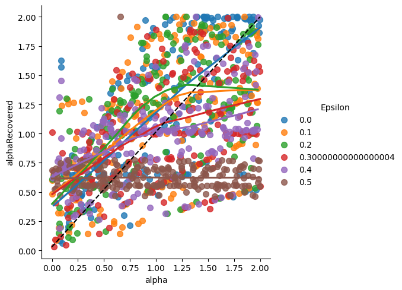

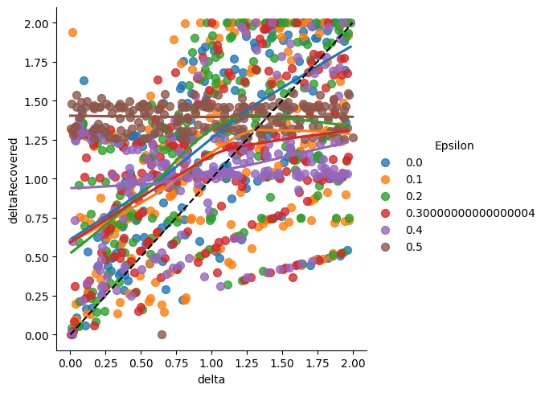

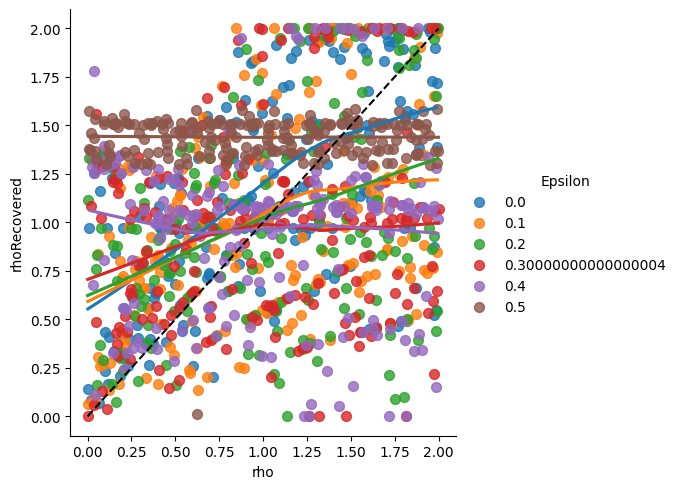

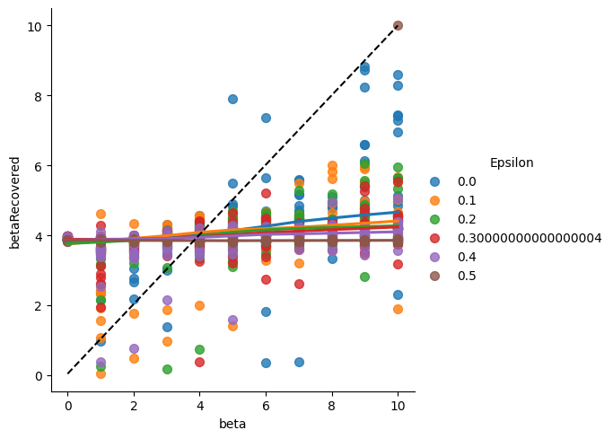

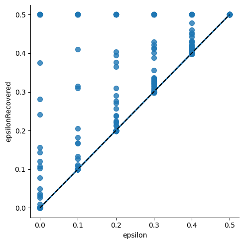

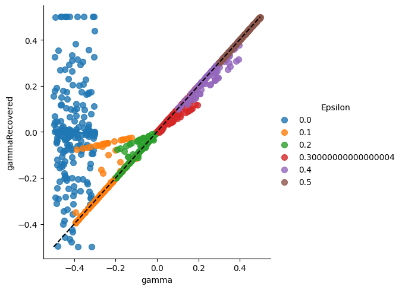

```python
import seaborn as sns
import matplotlib.pyplot as plt

freeParameters['Epsilon'] = freeParameters['epsilon'].astype('category')

sns.lmplot(data=freeParameters, x='alpha', y='alphaRecovered', hue='Epsilon', lowess=True, ci=None, scatter_kws={'s': 50})
plt.plot([freeParameters['alpha'].min(), freeParameters['alpha'].max()],
         [freeParameters['alphaRecovered'].min(), freeParameters['alphaRecovered'].max()], 'k--')
plt.show()

sns.lmplot(data=freeParameters, x='delta', y='deltaRecovered', hue='Epsilon', lowess=True, ci=None, scatter_kws={'s': 50})
plt.plot([freeParameters['delta'].min(), freeParameters['delta'].max()],
         [freeParameters['deltaRecovered'].min(), freeParameters['deltaRecovered'].max()], 'k--')
plt.show()

sns.lmplot(data=freeParameters, x='rho', y='rhoRecovered', hue='Epsilon', lowess=True, ci=None, scatter_kws={'s': 50})
plt.plot([freeParameters['rho'].min(), freeParameters['rho'].max()],
         [freeParameters['rhoRecovered'].min(), freeParameters['rhoRecovered'].max()], 'k--')
plt.show()

sns.lmplot(data=freeParameters, x='beta', y='betaRecovered', hue='Epsilon', lowess=True, ci=None, scatter_kws={'s': 50})
plt.plot([freeParameters['beta'].min(), freeParameters['beta'].max()],
         [freeParameters['betaRecovered'].min(), freeParameters['betaRecovered'].max()], 'k--')
plt.show()

sns.lmplot(data=freeParameters, x='epsilon', y='epsilonRecovered', lowess=True, ci=None, scatter_kws={'s': 50})
plt.plot([freeParameters['epsilon'].min(), freeParameters['epsilon'].max()],
         [freeParameters['epsilonRecovered'].min(), freeParameters['epsilonRecovered'].max()], 'k--')
plt.show()

sns.lmplot(data=freeParameters, x='gamma', y='gammaRecovered', hue='Epsilon', lowess=True, ci=None, scatter_kws={'s': 50})
plt.plot([freeParameters['gamma'].min(), freeParameters['gamma'].max()],
         [freeParameters['gammaRecovered'].min(), freeParameters['gammaRecovered'].max()], 'k--')
plt.show()
```

None of these look particularly reliable (even at low values of epsilon). The exception is epsilon.

## 2.1 Recovering Free Parameters

First let's get the trial data from participants

```python
trialData = pd.read_csv("C:/Users/DELL/Downloads/Data/Data/HPP_fMRI_beh_data_for_lmm.csv", sep=',')
trialData
```

|  | subject | trial_num | run | partnerA | partnerB | initial_A | initial_B | Pie_initial_high | Pie_initial_low | diff_initial | ... | TransferSize1_a | TransferSize2_a | TransferSize1_b | TransferSize2_b | Mah | Mal | Mbh | Mbl | Trans1_Diff | Trans2_Diff |
| --- | --- | --- | --- | --- | --- | --- | --- | --- | --- | --- | --- | --- | --- | --- | --- | --- | --- | --- | --- | --- | --- |
| 0 | 101 | 1 | 1 | 46 | 43 | 15 | 2 | 15 | 2 | 13 | ... | 5.0 | 0.0 | 1.0 | 0.0 | 10 | 7 | 14 | 3 | 4.0 | 0.0 |
| 1 | 101 | 2 | 1 | 82 | 1 | 16 | 5 | 16 | 5 | 11 | ... | 2.0 | 0.0 | 5.5 | 2.5 | 14 | 7 | 8 | 13 | 3.5 | 2.5 |
| 2 | 101 | 3 | 1 | 2 | 3 | 16 | 5 | 16 | 5 | 11 | ... | 2.0 | 0.0 | 3.0 | 0.0 | 14 | 7 | 13 | 8 | 1.0 | 0.0 |
| 3 | 101 | 4 | 1 | 42 | 47 | 15 | 3 | 15 | 3 | 12 | ... | 5.0 | 0.0 | 1.0 | 0.0 | 10 | 8 | 14 | 4 | 4.0 | 0.0 |
| 4 | 101 | 5 | 1 | 62 | 67 | 5 | 15 | 15 | 5 | 10 | ... | 5.0 | 2.0 | 5.0 | 0.0 | 8 | 12 | 10 | 10 | 0.0 | 2.0 |
| ... | ... | ... | ... | ... | ... | ... | ... | ... | ... | ... | ... | ... | ... | ... | ... | ... | ... | ... | ... | ... | ... |
| 9099 | 161 | 158 | 3 | 28 | 29 | 16 | 5 | 16 | 5 | 11 | ... | 1.0 | 0.0 | 5.5 | 3.5 | 15 | 6 | 7 | 14 | 4.5 | 3.5 |
| 9100 | 161 | 159 | 3 | 26 | 27 | 16 | 2 | 16 | 2 | 14 | ... | 5.0 | 0.0 | 1.0 | 0.0 | 11 | 7 | 15 | 3 | 4.0 | 0.0 |
| 9101 | 161 | 160 | 3 | 50 | 51 | 16 | 3 | 16 | 3 | 13 | ... | 5.0 | 0.0 | 1.0 | 0.0 | 11 | 8 | 15 | 4 | 4.0 | 0.0 |
| 9102 | 161 | 161 | 3 | 82 | 1 | 2 | 16 | 16 | 2 | 14 | ... | 5.0 | 0.0 | 2.0 | 0.0 | 11 | 7 | 14 | 4 | 3.0 | 0.0 |
| 9103 | 161 | 162 | 3 | 34 | 39 | 3 | 15 | 15 | 3 | 12 | ... | 1.0 | 0.0 | 6.0 | 3.0 | 14 | 4 | 6 | 12 | 5.0 | 3.0 |

9104 rows × 51 columns

```python
trialData = trialData.iloc[np.where(trialData['trail_type'] == 3)[0].tolist(), :]
trialData = trialData.iloc[:, [0,5,6,12,13,20,21,35]]
trialData.columns = ['SubjectID', 'a0', 'b0', 'a1', 'b1', 'a2', 'b2', 'Chose1']
trialData['Chose1'] -= 1
trialData['Prob1'] = 0.0
trialData
```

|  | SubjectID | a0 | b0 | a1 | b1 | a2 | b2 | Chose1 | Prob1 |
| --- | --- | --- | --- | --- | --- | --- | --- | --- | --- |
| 1 | 101 | 16 | 5 | 14 | 7 | 8 | 13 | 1 | 0.0 |
| 6 | 101 | 16 | 1 | 5 | 12 | 15 | 2 | 0 | 0.0 |
| 8 | 101 | 16 | 3 | 15 | 4 | 5 | 14 | 0 | 0.0 |
| 12 | 101 | 5 | 16 | 11 | 10 | 7 | 14 | 0 | 0.0 |
| 14 | 101 | 15 | 2 | 8 | 9 | 13 | 4 | 0 | 0.0 |
| ... | ... | ... | ... | ... | ... | ... | ... | ... | ... |
| 9094 | 161 | 15 | 3 | 12 | 6 | 7 | 11 | 1 | 0.0 |
| 9096 | 161 | 2 | 16 | 11 | 7 | 4 | 14 | 1 | 0.0 |
| 9097 | 161 | 16 | 3 | 8 | 11 | 15 | 4 | 0 | 0.0 |
| 9099 | 161 | 16 | 5 | 15 | 6 | 7 | 14 | 1 | 0.0 |
| 9103 | 161 | 3 | 15 | 4 | 14 | 12 | 6 | 1 | 0.0 |

3704 rows × 9 columns

Now we can define some necessary variables and functions

```python
included_subjects = trialData['SubjectID'].unique()
subjectData = pd.DataFrame()

def grab_data(subject):
    return trialData[trialData['SubjectID'] == subject].drop(columns=['SubjectID'])

def addPredictions(trialData, subject, predictions):
    trialData.loc[trialData['SubjectID'] == subject, 'Prob1'] = predictions
    return trialData
```

Which allows us to Recover Free Parameters and Define Predicted Decisions

```python
for i in range(0, len(included_subjects)):
    df = grab_data(included_subjects[i])
    result = optimize(obj_function, initial_params, lower_bounds, upper_bounds, df)
    df['Prob1'] = generatePredictions(result.x, df)
    model_SS = np.sum((df['Chose1'] - df['Prob1']) ** 2)
    model_NLL = -2 * np.sum(df['Chose1'] * np.log(df['Prob1']) + (1 - df['Chose1']) * np.log(1 - df['Prob1']))
    subjectData.loc[i, range(0, 9)] = [included_subjects[i]] + result.x.tolist() + [model_SS, model_NLL]
    trialData = addPredictions(trialData, included_subjects[i], df['Prob1'])

subjectData.columns = ["subjectID", "Alpha", "Delta", "Rho", "Beta", "Epsilon", "Gamma", "SS", "Deviance"]
subjectData
```

|  | subjectID | Alpha | Delta | Rho | Beta | Epsilon | Gamma | SS | Deviance |
| --- | --- | --- | --- | --- | --- | --- | --- | --- | --- |
| 0 | 101 | 0.584786 | 1.40451 | 1.391285 | 3.953151 | 0.439418 | -0.051706 | 16.121213 | 89.968933 |
| 1 | 102 | 1.861284 | 0.286077 | 0.128607 | 2.667363 | 0.125858 | -0.343707 | 7.362723 | 48.49021 |
| 2 | 103 | 1.997318 | 0.0 | 0.001881 | 3.868219 | 0.015625 | -0.5 | 0.96875 | 8.899898 |
| 3 | 104 | 1.190624 | 0.0 | 1.923085 | 6.183159 | 0.0 | -0.5 | 0.944444 | 7.724131 |
| 4 | 105 | 0.413044 | 1.588756 | 1.596434 | 3.918338 | 0.03125 | -0.5 | 1.875 | 14.962666 |
| 5 | 106 | 1.92463 | 0.064715 | 0.149616 | 3.780281 | 0.152932 | -0.193507 | 8.233913 | 54.01814 |
| 6 | 107 | 0.606605 | 1.387175 | 1.364644 | 3.937234 | 0.227273 | -0.100002 | 11.454549 | 69.966089 |
| 7 | 108 | 2.0 | 2.0 | 0.954854 | 10.0 | 0.420142 | -0.169416 | 15.423638 | 87.060605 |
| 8 | 109 | 0.603062 | 1.399898 | 1.410025 | 3.908818 | 0.34375 | -0.272727 | 12.187502 | 71.973876 |
| 9 | 110 | 0.275171 | 1.732045 | 1.764335 | 3.930266 | 0.064516 | -0.5 | 3.483871 | 23.841661 |
| 10 | 111 | 2.0 | 0.0 | 0.0 | 5.323537 | 0.0 | -0.5 | 0.0 | 0.0 |
| 11 | 112 | 1.912189 | 2.0 | 0.0 | 4.190076 | 0.284814 | -0.12765 | 13.926193 | 80.428365 |
| 12 | 113 | 2.0 | 0.0 | 0.0 | 5.323537 | 0.0 | -0.5 | 0.0 | 0.0 |
| 13 | 114 | 1.016655 | 0.074773 | 0.792054 | 3.610672 | 0.182567 | -0.330024 | 9.660096 | 60.151431 |
| 14 | 115 | 2.0 | 0.0 | 0.0 | 3.809524 | 0.136364 | -0.5 | 6.545455 | 38.672879 |
| 15 | 116 | 2.0 | 0.0 | 0.0 | 3.824639 | 0.090909 | -0.5 | 4.909091 | 31.293201 |
| 16 | 117 | 0.664163 | 1.328325 | 1.308432 | 3.973002 | 0.245738 | -0.05492 | 12.014215 | 72.293494 |
| 17 | 118 | 1.990323 | 0.0 | 0.047236 | 4.058352 | 0.197917 | -0.342105 | 9.208333 | 56.972602 |
| 18 | 119 | 2.0 | 0.0 | 0.0 | 3.263192 | 0.015152 | -0.5 | 0.969697 | 8.962476 |
| 19 | 120 | 0.658054 | 1.341836 | 1.341156 | 3.971277 | 0.5 | -0.084615 | 15.784615 | 88.238606 |
| 20 | 121 | 0.603775 | 1.397623 | 1.403888 | 3.948822 | 0.5 | -0.161538 | 14.553846 | 83.201267 |
| 21 | 122 | 2.0 | 0.0 | 0.0 | 5.232726 | 0.0 | -0.5 | 0.0 | 0.0 |
| 22 | 124 | 2.0 | 0.575156 | 0.0 | 10.0 | 0.289058 | -0.048559 | 13.815961 | 80.411185 |
| 23 | 125 | 1.829199 | 0.0 | 0.316402 | 6.14335 | 0.030303 | 0.5 | 1.878788 | 15.089704 |
| 24 | 126 | 0.618671 | 1.386061 | 1.407523 | 3.945943 | 0.5 | -0.25 | 12.0 | 71.978899 |
| 25 | 127 | 0.700813 | 1.300735 | 1.301627 | 3.919579 | 0.5 | -0.075758 | 16.121212 | 89.974425 |
| 26 | 128 | 2.0 | 0.0 | 0.0 | 3.446722 | 0.045455 | -0.5 | 2.727273 | 20.106016 |
| 27 | 129 | 1.017367 | 0.820164 | 2.0 | 10.0 | 0.270511 | -0.282199 | 13.442522 | 77.578393 |
| 28 | 130 | 1.999353 | 0.0 | 0.002408 | 3.890866 | 0.015625 | -0.5 | 0.96875 | 8.899897 |
| 29 | 131 | 1.94839 | 0.0 | 0.10273 | 3.850482 | 0.090909 | -0.166669 | 5.39394 | 39.465704 |
| 30 | 132 | 0.473994 | 1.525386 | 1.522669 | 3.958936 | 0.121212 | -0.375 | 6.484849 | 43.068138 |
| 31 | 133 | 0.644173 | 1.356482 | 1.360095 | 3.937134 | 0.378788 | -0.18 | 14.303024 | 82.272022 |
| 32 | 134 | 0.707343 | 1.294187 | 1.297907 | 3.932183 | 0.5 | -0.084615 | 15.784615 | 88.238606 |
| 33 | 135 | 0.682981 | 1.315112 | 1.310409 | 3.989874 | 0.383517 | -0.092584 | 15.056796 | 85.224028 |
| 34 | 136 | 1.908223 | 0.0 | 0.083224 | 4.100114 | 0.10606 | -0.357143 | 5.878788 | 40.255603 |
| 35 | 138 | 0.62348 | 1.377209 | 1.379891 | 3.929145 | 0.357142 | -0.2 | 12.214288 | 70.685309 |
| 36 | 140 | 1.503304 | 1.544245 | 2.0 | 10.0 | 0.367878 | -0.005744 | 15.137717 | 85.607636 |
| 37 | 141 | 1.999946 | 1.714483 | 2.0 | 10.0 | 0.41567 | -0.101035 | 15.333749 | 85.639322 |
| 38 | 142 | 0.707805 | 1.292332 | 1.292742 | 3.947363 | 0.5 | -0.060606 | 16.257576 | 90.523342 |
| 39 | 143 | 0.604117 | 1.395521 | 1.333639 | 3.968155 | 0.5 | -0.115385 | 15.384615 | 86.616198 |
| 40 | 144 | 1.997052 | 0.0 | 0.0 | 3.813054 | 0.016129 | -0.5 | 0.967742 | 8.835372 |
| 41 | 145 | 0.654331 | 1.346731 | 1.353118 | 3.96669 | 0.5 | -0.129032 | 14.467742 | 81.774121 |
| 42 | 146 | 0.625228 | 1.376068 | 1.329301 | 3.969417 | 0.5 | -0.136364 | 15.272727 | 86.523594 |
| 43 | 147 | 0.0 | 2.0 | 2.0 | 3.877126 | 0.0 | -0.5 | 0.0 | 0.0 |
| 44 | 148 | 2.0 | 0.0 | 0.0 | 3.337756 | 0.090909 | -0.5 | 4.909091 | 31.293242 |
| 45 | 149 | 2.0 | 0.362832 | 0.0 | 10.0 | 0.0 | -0.5 | 0.502106 | 2.875238 |
| 46 | 150 | 0.626717 | 1.372199 | 1.367735 | 4.004656 | 0.326042 | -0.164537 | 12.835417 | 74.674468 |
| 47 | 151 | 1.865852 | 0.012877 | 0.105642 | 3.952177 | 0.221422 | -0.177361 | 9.728573 | 59.618382 |
| 48 | 152 | 1.985764 | 0.014218 | 0.012964 | 3.70961 | 0.19697 | -0.038461 | 10.424242 | 65.398929 |
| 49 | 153 | 0.645895 | 1.267619 | 1.310501 | 3.962139 | 0.409101 | 0.055563 | 15.818202 | 88.73649 |
| 50 | 154 | 2.0 | 0.0 | 0.000589 | 2.903617 | 0.030303 | -0.000066 | 1.939403 | 17.925118 |
| 51 | 155 | 1.987186 | 0.331485 | 0.129589 | 3.850823 | 0.045149 | 0.117904 | 3.449123 | 27.490567 |
| 52 | 156 | 0.533297 | 1.465932 | 1.462514 | 3.964502 | 0.045455 | -0.166662 | 2.848485 | 24.052101 |
| 53 | 157 | 0.077654 | 0.000113 | 0.189579 | 9.999619 | 0.168149 | -0.5 | 13.293275 | 77.290669 |
| 54 | 158 | 0.714876 | 1.285201 | 1.285443 | 3.937583 | 0.484852 | -0.0625 | 16.242433 | 90.461857 |
| 55 | 160 | 0.628207 | 1.358566 | 1.303138 | 3.963916 | 0.153409 | 0.092581 | 8.409102 | 55.406565 |
| 56 | 161 | 0.634225 | 1.367438 | 1.374983 | 3.986785 | 0.412879 | -0.197248 | 14.060608 | 80.97667 |

## 2.2 Compute Model Fit Index

We will calculate BIC as the model fit index because we are attempting to model the probabilistic nature of the data generation process.

```python
subjectData['BIC'] = subjectData['Deviance'] + np.log(65) * 6
```

## 2.3 Identity the Best Model

We need to define new objective functions for each model. Since each model uses the same utility function, but holds some variables constant (at 0), we only really need to modify the number of parameter inputs and set the constant values to 0. We can also use a list of indices so that the we can use the same function to generate predictions down the line.

```python
def of_alphaOnly(params, df, optimMethod="MLE"):
    params_new = np.zeros(6)
    params_new[[0, 3, 4, 5]] = params
    Prob1 = generatePredictions(params_new, df)
    Chose1 = df.iloc[:, 6]
    if optimMethod == "OLS":
        return np.sum((Chose1 - Prob1)**2)
    elif optimMethod == "MLE":
        return -np.sum(Chose1 * np.log(Prob1) + (1 - Chose1) * np.log(1 - Prob1))

def of_deltaOnly(params, df, optimMethod="MLE"):
    params_new = np.zeros(6)
    params_new[[1, 3, 4, 5]] = params
    Prob1 = generatePredictions(params_new, df)
    Chose1 = df.iloc[:, 6]
    if optimMethod == "OLS":
        return np.sum((Chose1 - Prob1)**2)
    elif optimMethod == "MLE":
        return -np.sum(Chose1 * np.log(Prob1) + (1 - Chose1) * np.log(1 - Prob1))

def of_rhoOnly(params, df, optimMethod="MLE"):
    params_new = np.zeros(6)
    params_new[[2, 3, 4, 5]] = params
    Prob1 = generatePredictions(params_new, df)
    Chose1 = df.iloc[:, 6]
    if optimMethod == "OLS":
        return np.sum((Chose1 - Prob1)**2)
    elif optimMethod == "MLE":
        return -np.sum(Chose1 * np.log(Prob1) + (1 - Chose1) * np.log(1 - Prob1))

def of_ad(params, df, optimMethod="MLE"):
    params_new = np.zeros(6)
    params_new[[0, 1, 3, 4, 5]] = params
    Prob1 = generatePredictions(params_new, df)
    Chose1 = df.iloc[:, 6]
    if optimMethod == "OLS":
        return np.sum((Chose1 - Prob1)**2)
    elif optimMethod == "MLE":
        return -np.sum(Chose1 * np.log(Prob1) + (1 - Chose1) * np.log(1 - Prob1))

def of_ar(params, df, optimMethod="MLE"):
    params_new = np.zeros(6)
    params_new[[0, 2, 3, 4, 5]] = params
    Prob1 = generatePredictions(params_new, df)
    Chose1 = df.iloc[:, 6]
    if optimMethod == "OLS":
        return np.sum((Chose1 - Prob1)**2)
    elif optimMethod == "MLE":
        return -np.sum(Chose1 * np.log(Prob1) + (1 - Chose1) * np.log(1 - Prob1))

def of_dr(params, df, optimMethod="MLE"):
    params_new = np.zeros(6)
    params_new[[1, 2, 3, 4, 5]] = params
    Prob1 = generatePredictions(params_new, df)
    Chose1 = df.iloc[:, 6]
    if optimMethod == "OLS":
        return np.sum((Chose1 - Prob1)**2)
    elif optimMethod == "MLE":
        return -np.sum(Chose1 * np.log(Prob1) + (1 - Chose1) * np.log(1 - Prob1))

def of_noEpsilon(params, df, optimMethod="MLE"):
    params_new = np.zeros(6)
    params_new[[0, 1, 2, 3]] = params
    Prob1 = generatePredictions(params_new, df)
    Chose1 = df.iloc[:, 6]
    if optimMethod == "OLS":
        return np.sum((Chose1 - Prob1)**2)
    elif optimMethod == "MLE":
        return -np.sum(Chose1 * np.log(Prob1) + (1 - Chose1) * np.log(1 - Prob1))

def of_noGamma(params, df, optimMethod="MLE"):
    params_new = np.zeros(6)
    params_new[[0, 1, 2, 3, 4]] = params
    Prob1 = generatePredictions(params_new, df)
    Chose1 = df.iloc[:, 6]
    if optimMethod == "OLS":
        return np.sum((Chose1 - Prob1)**2)
    elif optimMethod == "MLE":
        return -np.sum(Chose1 * np.log(Prob1) + (1 - Chose1) * np.log(1 - Prob1))

def of_GammaOnly(params, df, optimMethod="MLE"):
    params_new = np.zeros(6)
    params_new[4] = 0.5
    params_new[5] = params
    Prob1 = generatePredictions(params_new, df)
    Chose1 = df.iloc[:, 6]
    if optimMethod == "OLS":
        return np.sum((Chose1 - Prob1)**2)
    elif optimMethod == "MLE":
        return -np.sum(Chose1 * np.log(Prob1) + (1 - Chose1) * np.log(1 - Prob1))

ofs = [of_alphaOnly, of_deltaOnly, of_rhoOnly, of_ad, of_ar, of_dr, of_noEpsilon, of_noGamma, of_GammaOnly]
idxs = [[0, 3, 4, 5], [1, 3, 4, 5], [2, 3, 4, 5], [0, 1, 3, 4, 5], [0, 2, 3, 4, 5], [1, 2, 3, 4, 5], [0, 1, 2, 3], [0, 1, 2, 3, 4], [5]]
```

And now we can preallocate the predictions for each model and the new data frame

```python
altSubjectData = pd.DataFrame()
altTrialData = trialData.drop(columns=[trialData.columns[8]])
```

Now let's Recover Free Parameters and Generate Predictions for this Model

```python
for i in range(0, len(included_subjects)):
    df = grab_data(included_subjects[i])
    outputs = []
    j = 0

    for k in range(0, len(idxs)):
        idx = idxs[k]
        initials = [initial_params[i] for i in idx]
        uppers = [upper_bounds[i] for i in idx]
        lowers = [lower_bounds[i] for i in idx]
        of = ofs[k]

        result = optimize(of, initials, lowers, uppers, df)

        pars = np.zeros(6)
        pars[idx] = result.x
        if len(idx) == 1:
            pars[4] = 0.5

        df['Prob1'] = generatePredictions(pars, df)

        model_SS = np.sum((df['Chose1'] - df['Prob1'])**2)
        model_NLL = -2 * np.sum(df['Chose1'] * np.log(df['Prob1']) + (1 - df['Chose1']) * np.log(1 - df['Prob1']))
        outputs = outputs + result.x.tolist() + [model_SS, model_NLL]
        j += 2 + len(result.x)

        altTrialData.loc[altTrialData['SubjectID'] == included_subjects[i], 8 + k] = df['Prob1']

    altSubjectData.loc[i, range(0, 56)] = [included_subjects[i]] + outputs

altSubjectData.columns = [
    'SubjectID',
    'Alpha_M1', 'Beta_M1', 'Epsilon_M1', 'Gamma_M1', 'SS_M1', 'Deviance_M1',
    'Delta_M2', 'Beta_M2', 'Epsilon_M2', 'Gamma_M2', 'SS_M2', 'Deviance_M2',
    'Rho_M3', 'Beta_M3', 'Epsilon_M3', 'Gamma_M3', 'SS_M3', 'Deviance_M3',
    'Alpha_M4', 'Delta_M4', 'Beta_M4', 'Epsilon_M4', 'Gamma_M4', 'SS_M4', 'Deviance_M4',
    'Alpha_M5', 'Rho_M5', 'Beta_M5', 'Epsilon_M5', 'Gamma_M5', 'SS_M5', 'Deviance_M5',
    'Delta_M6', 'Rho_M6', 'Beta_M6', 'Epsilon_M6', 'Gamma_M6', 'SS_M6', 'Deviance_M6',
    'Alpha_M7', 'Delta_M7', 'Rho_M7', 'Beta_M7', 'SS_M7', 'Deviance_M7',
    'Alpha_M8', 'Delta_M8', 'Rho_M8', 'Beta_M8', 'Epsilon_M8', 'SS_M8', 'Deviance_M8',
    'Gamma_M9', 'SS_M9', 'Deviance_M9'
]

altTrialData.columns = ['SubjectID', 'a0', 'b0', 'a1', 'b1', 'a2', 'b2', 'Chose1','alphaOnly_Prob1', 'deltaOnly_Prob1', 'rhoOnly_Prob1', 'ad_Prob1', 'ar_Prob1', 'dr_Prob1', 'noEpsilon_Prob1', 'noGamma_Prob1', 'gammaOnly_Prob1']

for col in altSubjectData.columns[1:]:
    altSubjectData[col] = pd.to_numeric(altSubjectData[col])
```

Now let's glance at the trial level data for these alternative models

```python
altTrialData
```

|  | SubjectID | a0 | b0 | a1 | b1 | a2 | b2 | Chose1 | alphaOnly_Prob1 | deltaOnly_Prob1 | rhoOnly_Prob1 | ad_Prob1 | ar_Prob1 | dr_Prob1 | noEpsilon_Prob1 | noGamma_Prob1 | gammaOnly_Prob1 |
| --- | --- | --- | --- | --- | --- | --- | --- | --- | --- | --- | --- | --- | --- | --- | --- | --- | --- |
| 1 | 101 | 16 | 5 | 14 | 7 | 8 | 13 | 1 | 0.454545 | 0.515152 | 0.515151 | 0.515148 | 0.454546 | 0.515152 | 0.5 | 0.560606 | 0.454545 |
| 6 | 101 | 16 | 1 | 5 | 12 | 15 | 2 | 0 | 0.454545 | 0.393939 | 0.393939 | 0.393934 | 0.454546 | 0.393939 | 0.5 | 0.439394 | 0.454545 |
| 8 | 101 | 16 | 3 | 15 | 4 | 5 | 14 | 0 | 0.454545 | 0.515152 | 0.515151 | 0.515148 | 0.454546 | 0.515152 | 0.5 | 0.560606 | 0.454545 |
| 12 | 101 | 5 | 16 | 11 | 10 | 7 | 14 | 0 | 0.454545 | 0.393939 | 0.393939 | 0.393934 | 0.454546 | 0.393939 | 0.5 | 0.439394 | 0.454545 |
| 14 | 101 | 15 | 2 | 8 | 9 | 13 | 4 | 0 | 0.454545 | 0.393939 | 0.393939 | 0.393934 | 0.454546 | 0.393939 | 0.5 | 0.439394 | 0.454545 |
| ... | ... | ... | ... | ... | ... | ... | ... | ... | ... | ... | ... | ... | ... | ... | ... | ... | ... |
| 9094 | 161 | 15 | 3 | 12 | 6 | 7 | 11 | 1 | 0.338462 | 0.424242 | 0.424242 | 0.424245 | 0.338462 | 0.424242 | 0.5 | 0.584615 | 0.338462 |
| 9096 | 161 | 2 | 16 | 11 | 7 | 4 | 14 | 1 | 0.338462 | 0.250000 | 0.250000 | 0.250007 | 0.338462 | 0.250000 | 0.5 | 0.415385 | 0.338462 |
| 9097 | 161 | 16 | 3 | 8 | 11 | 15 | 4 | 0 | 0.338462 | 0.250000 | 0.250000 | 0.250007 | 0.338462 | 0.250000 | 0.5 | 0.415385 | 0.338462 |
| 9099 | 161 | 16 | 5 | 15 | 6 | 7 | 14 | 1 | 0.338462 | 0.424242 | 0.424242 | 0.424245 | 0.338462 | 0.424242 | 0.5 | 0.584615 | 0.338462 |
| 9103 | 161 | 3 | 15 | 4 | 14 | 12 | 6 | 1 | 0.338462 | 0.424242 | 0.424242 | 0.424245 | 0.338462 | 0.424242 | 0.5 | 0.584615 | 0.338462 |

3704 rows × 17 columns

Now we can compute BIC for these models

```python
altSubjectData['BIC_M1'] = altSubjectData['Deviance_M1'] + np.log(65) * 4
altSubjectData['BIC_M2'] = altSubjectData['Deviance_M2'] + np.log(65) * 4
altSubjectData['BIC_M3'] = altSubjectData['Deviance_M3'] + np.log(65) * 4
altSubjectData['BIC_M4'] = altSubjectData['Deviance_M4'] + np.log(65) * 5
altSubjectData['BIC_M5'] = altSubjectData['Deviance_M5'] + np.log(65) * 5
altSubjectData['BIC_M6'] = altSubjectData['Deviance_M6'] + np.log(65) * 5
altSubjectData['BIC_M7'] = altSubjectData['Deviance_M7'] + np.log(65) * 4
altSubjectData['BIC_M8'] = altSubjectData['Deviance_M8'] + np.log(65) * 5
altSubjectData['BIC_M9'] = altSubjectData['Deviance_M9'] + np.log(65) * 1
```

And now we can compare the BIC of all of the models

```python
modelBIC = [subjectData['BIC'].sum(), altSubjectData['BIC_M1'].sum(), altSubjectData['BIC_M2'].sum(), altSubjectData['BIC_M3'].sum(), altSubjectData['BIC_M4'].sum(), altSubjectData['BIC_M5'].sum(), altSubjectData['BIC_M6'].sum(), altSubjectData['BIC_M7'].sum(), altSubjectData['BIC_M8'].sum(), altSubjectData['BIC_M9'].sum()]
print(np.argmin(modelBIC))
```

```
4
```

This analysis indicates that the best model has Alpha, Delta, Beta, Epsilon, and Gamma - not Rho (i.e. Rank Reversal Aversion).

## Validate the Best Model

First, let's assess model performance at a basic level: we can look at prediction accuracy to begin

```python
print(np.sum(altTrialData['Chose1'] == np.round(altTrialData['ad_Prob1'])) / len(altTrialData))
```

```
0.7899568034557235
```

Next, we can proceed to look at the distribution of model accuracy across participants

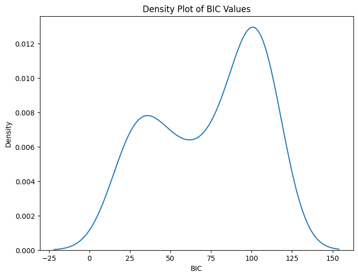

```python
altTrialData['a0-a1'] = altTrialData['a0']-altTrialData['a1']
altTrialData['a0-a2'] = altTrialData['a0']-altTrialData['a2']
altTrialData['b0-b1'] = altTrialData['b0']-altTrialData['b1']
altTrialData['b0-b2'] = altTrialData['b0']-altTrialData['b2']
altTrialData['a1-a2'] = altTrialData['a1']-altTrialData['a2']
altTrialData['b1-b2'] = altTrialData['b1']-altTrialData['b2']
altTrialData['a0_less_than_b0'] = trialData['a0'] < trialData['b0']
altTrialData['Chose1 - Prob1'] = altTrialData['Chose1']-altTrialData['ad_Prob1']

plt.figure(figsize=(8, 6))
sns.kdeplot(altSubjectData['BIC_M4'])
plt.title('Density Plot of BIC Values')
plt.xlabel('BIC')
plt.ylabel('Density')
plt.show()
```

Let's look at the bottom 25% of model performance:

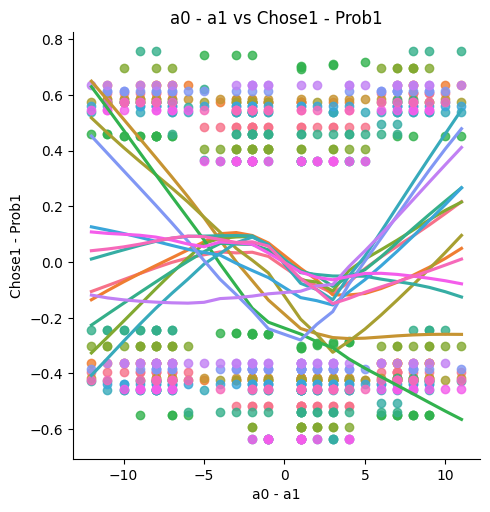

```python
bic_summary = altSubjectData['BIC_M4'].describe()
worst_explained = altSubjectData.index[altSubjectData['BIC_M4'] > bic_summary['75%']].tolist()
worst_subject_ids = altSubjectData['SubjectID'].iloc[worst_explained]
filtered_trialData = altTrialData[altTrialData['SubjectID'].isin(worst_subject_ids)]

sns.lmplot(data=filtered_trialData, x='a0-a1', y='Chose1 - Prob1', hue='SubjectID', legend=False, lowess=True)
plt.title('a0 - a1 vs Chose1 - Prob1')
plt.xlabel('a0 - a1')
plt.ylabel('Chose1 - Prob1')
plt.show()
```

This looks systematic

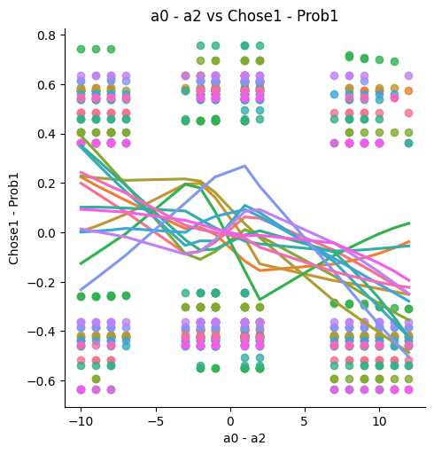

```python
sns.lmplot(data=filtered_trialData, x='a0-a2', y='Chose1 - Prob1', hue='SubjectID', legend=False, lowess=True)
plt.title('a0 - a2 vs Chose1 - Prob1')
plt.xlabel('a0 - a2')
plt.ylabel('Chose1 - Prob1')
plt.show()
```

Not as much here, but still some directionality within people

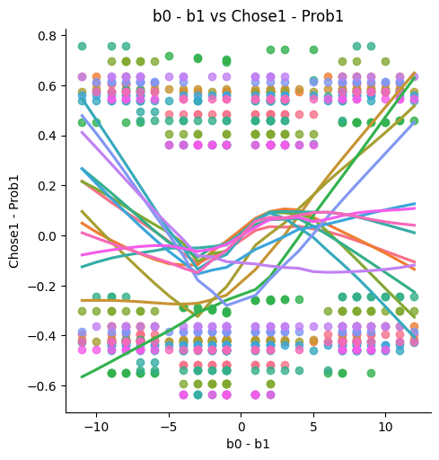

```python
sns.lmplot(data=filtered_trialData, x='b0-b1', y='Chose1 - Prob1', hue='SubjectID', legend=False, lowess=True)
plt.title('b0 - b1 vs Chose1 - Prob1')
plt.xlabel('b0 - b1')
plt.ylabel('Chose1 - Prob1')
plt.show()
```

Same here, not as bad as the first but still not so great.

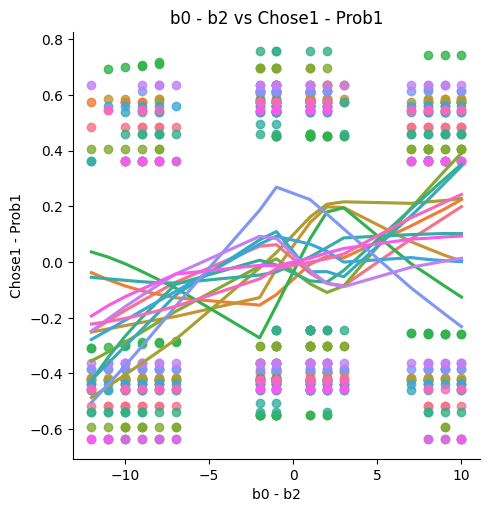

```python
sns.lmplot(data=filtered_trialData, x='b0-b2', y='Chose1 - Prob1', hue='SubjectID', legend=False, lowess=True)
plt.title('b0 - b2 vs Chose1 - Prob1')
plt.xlabel('b0 - b2')
plt.ylabel('Chose1 - Prob1')
plt.show()
```

And nothing here either. Now we can check assumptions: first linearity (we'll do this across both choices)

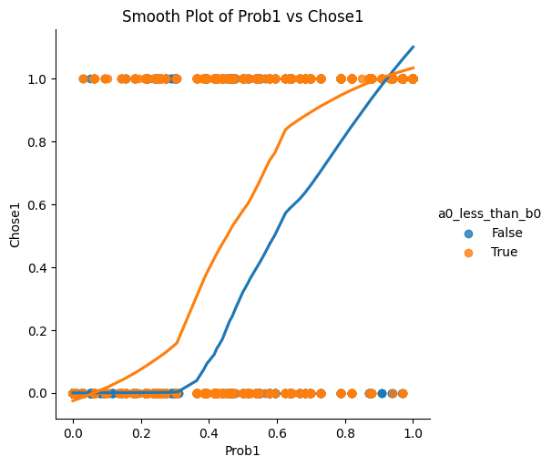

```python
sns.lmplot(data=altTrialData, x='ad_Prob1', y='Chose1', hue='a0_less_than_b0', lowess = True)
plt.title('Smooth Plot of Prob1 vs Chose1')
plt.xlabel('Prob1')
plt.ylabel('Chose1')
plt.show()
```

It seems that something about a0 and b0 is different: our model seems unable to account for this bias so that's slightly alarming. Looks okay, not exactly perfect but still decent. Second, normality of error:

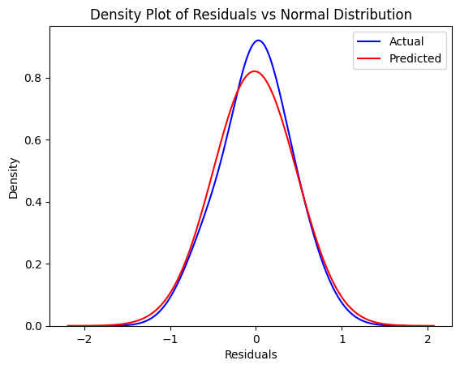

```python
residuals = altTrialData['ad_Prob1'] - trialData['Chose1']
altTrialData['residuals'] = residuals
normvals = np.random.normal(loc=0, scale=np.std(residuals), size=1000)

sns.kdeplot(residuals, bw_adjust=np.std(normvals)*10, label='Actual', color='blue')
sns.kdeplot(normvals, bw_adjust=np.std(normvals)*10, label='Predicted', color='red')
plt.title('Density Plot of Residuals vs Normal Distribution')
plt.xlabel('Residuals')
plt.ylabel('Density')
plt.legend()
plt.show()
```

For this one, I played with the factor that I multiplied the standard deviation of the normvals by in assessing the bw_adjust argument. You can see that if you set it to 1 (i.e. the standard deviation), the distributions look very choppy. Here, we want to use the theoretical (i.e. normvals) standard deviation to avoid any bias in the empirical data. We see that the distribution looks mostly normal, not visually skewed and somewhat lepokurtic - not super problematic though. Third we can examine homoscedasticity:

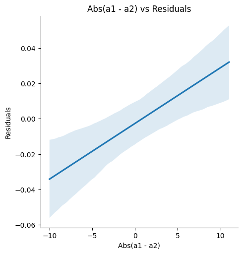

```python
sns.lmplot(data=altTrialData, x='a1-a2', y='residuals', scatter=False)
plt.title('Abs(a1 - a2) vs Residuals')
plt.xlabel('Abs(a1 - a2)')
plt.ylabel('Residuals')
plt.show()
```

Nice constant variance cloud, slightly positive but looking at the X axis, we can see that the discrepency is about 6% over all ranges of values so it's not cataclysmic. And finally independence of error:

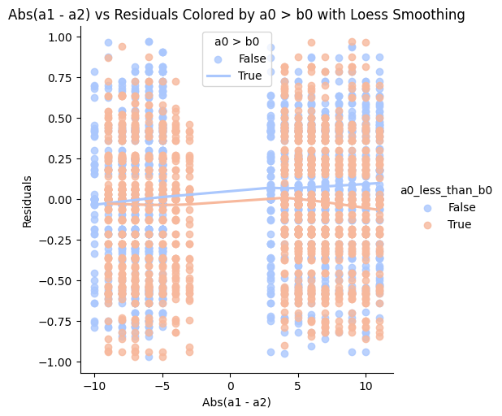

```python
sns.lmplot(data=altTrialData, x='a1-a2', y='residuals', hue='a0_less_than_b0', palette='coolwarm', lowess=True)
plt.title('Abs(a1 - a2) vs Residuals Colored by a0 > b0 with Loess Smoothing')
plt.xlabel('Abs(a1 - a2)')
plt.ylabel('Residuals')
plt.legend(title='a0 > b0', labels=['False', 'True'])
plt.show()
```

Again, not perfect but not horrible either.

If you want to assess independence explicitly, you can run the analysis in R. Running lmer models in Python with random slopes requires (to the best of my knowledge) you to use packages that allow you to run R processes anyways so no need to overcomplicate things. This step is extra really, so you don't fully need to do it.

Let's jump to fivefold validation

```python
fivefold = pd.DataFrame()
trialData['Prob1_ff'] = 0.0
initial_params = [1, 1, 4, 0.25, 0]
lower_bounds = [0, 0, 0, 0, -0.5]
upper_bounds = [2, 2, 10, 0.5, 0.5]

for i in range(0, len(included_subjects)):
    df = grab_data(included_subjects[i])
    df = df.reset_index()
    df['Prob1'] = 0.0

    order = np.random.permutation(len(df))

    A_ff, D_ff, B_ff, E_ff, G_ff = np.zeros(5), np.zeros(5), np.zeros(5), np.zeros(5), np.zeros(5)
    Deviance_ff = 0.0

    for z in range(5):
        j = int((z) * (len(df) / 5))
        n = int((z+1) * (len(df) / 5))
        withheld = order[j:n]

        input = df.iloc[~df.index.isin(withheld)]
        input = input.loc[:, ['a0', 'b0', 'a1', 'b1', 'a2', 'b2', 'Chose1', 'Prob1']]

        result_ff = optimize(of_ad, initial_params, lower_bounds, upper_bounds, input)

        A_ff[z], D_ff[z], B_ff[z], E_ff[z], G_ff[z] = result_ff.x
        input = df.iloc[df.index.isin(withheld)]
        input = input.loc[:, ['a0', 'b0', 'a1', 'b1', 'a2', 'b2', 'Chose1', 'Prob1']]
        pars = result_ff.x[0:2].tolist() + [0] + result_ff.x[2:].tolist()
        df.loc[df.index.isin(withheld),'Prob1'] = generatePredictions(pars, input)

    Deviance_ff = -2 * np.sum(df['Chose1'] * np.log(df['Prob1']) + (1 - df['Chose1']) * np.log(1 - df['Prob1']))
    fivefold.loc[i, range(0, 27)] = [included_subjects[i], Deviance_ff] + list(A_ff) + list(D_ff) + list(B_ff) + list(E_ff) + list(G_ff)
    trialData.loc[trialData['SubjectID'] == included_subjects[i], 'Prob1_ff'] = df['Prob1']

fivefold.columns = ['SubjectID', 'Deviance', 'A_F1', 'A_F2', 'A_F3', 'A_F4', 'A_F5',
                    'D_F1', 'D_F2', 'D_F3', 'D_F4', 'D_F5', 'B_F1', 'B_F2', 'B_F3', 'B_F4', 'B_F5',
                    'E_F1', 'E_F2', 'E_F3', 'E_F4', 'E_F5', 'G_F1', 'G_F2', 'G_F3', 'G_F4', 'G_F5']
fivefold['BIC'] = fivefold['Deviance'] + np.log(65) * 6
fivefold
```

|  | SubjectID | Deviance | A_F1 | A_F2 | A_F3 | A_F4 | A_F5 | D_F1 | D_F2 | D_F3 | ... | E_F2 | E_F3 | E_F4 | E_F5 | G_F1 | G_F2 | G_F3 | G_F4 | G_F5 | BIC |
| --- | --- | --- | --- | --- | --- | --- | --- | --- | --- | --- | --- | --- | --- | --- | --- | --- | --- | --- | --- | --- | --- |
| 0 | 101 | 94.662923 | 0.732809 | 0.354739 | 0.331502 | 0.400575 | 0.417828 | 1.26598 | 1.615671 | 1.640032 | ... | 0.445652 | 0.397982 | 0.439139 | 0.400741 | -0.028302 | -0.060976 | -0.023464 | -0.044578 | -0.10074 | 119.709247 |
| 1 | 102 | 53.775535 | 1.969634 | 1.726968 | 1.950265 | 1.265814 | 1.755445 | 0.0 | 0.316329 | 0.036471 | ... | 0.146853 | 0.160146 | 0.105743 | 0.128804 | -0.328026 | -0.351669 | -0.228504 | -0.289725 | -0.309737 | 78.821859 |
| 2 | 103 | 48.042786 | 2.0 | 1.960569 | 2.0 | 2.0 | 1.997382 | 0.0 | 0.041674 | 0.0 | ... | 0.02 | 0.018519 | 0.019231 | 0.02 | -0.442497 | -0.5 | -0.5 | -0.5 | -0.5 | 73.08911 |
| 3 | 104 | 48.421689 | 1.904585 | 1.90967 | 2.0 | 0.341922 | 1.999884 | 0.029089 | 0.020498 | 0.0 | ... | 0.019227 | 0.0 | 0.0 | 0.019231 | 0.5 | 0.5 | -0.413866 | 0.5 | 0.5 | 73.468013 |
| 4 | 105 | 17.51788 | 0.115274 | 0.254777 | 0.299079 | 0.0 | 0.267777 | 1.884488 | 1.745034 | 1.700782 | ... | 0.04 | 0.041667 | 0.019231 | 0.04 | -0.5 | -0.5 | -0.5 | -0.5 | -0.5 | 42.564204 |
| 5 | 106 | 194.486106 | 1.934394 | 2.0 | 2.0 | 2.0 | 2.0 | 0.0 | 0.0 | 0.0 | ... | 0.153846 | 0.175557 | 0.189632 | 0.107143 | -0.071427 | -0.125 | -0.183552 | -0.183588 | -0.5 | 219.53243 |
| 6 | 107 | 74.922241 | 0.30171 | 0.280717 | 0.440849 | 0.397539 | 0.279366 | 1.67116 | 1.686129 | 1.52845 | ... | 0.220699 | 0.189261 | 0.242095 | 0.252981 | -0.092471 | -0.228268 | -0.028333 | -0.069695 | -0.076478 | 99.968565 |
| 7 | 108 | 93.705342 | 0.651836 | 0.627837 | 0.653785 | 0.0 | 0.664175 | 1.348312 | 1.362208 | 1.346603 | ... | 0.416631 | 0.492786 | 0.394269 | 0.5 | -0.084906 | -0.100009 | -0.124299 | -0.172526 | -0.096154 | 118.751666 |
| 8 | 109 | 82.812771 | 2.0 | 0.321854 | 0.454523 | 0.283007 | 0.243454 | 1.828888 | 1.657425 | 1.546519 | ... | 0.356916 | 0.328466 | 0.310768 | 0.349978 | -0.295899 | -0.284483 | -0.378217 | -0.242572 | -0.214299 | 107.859095 |
| 9 | 110 | 26.154502 | 0.171022 | 0.283111 | 0.390695 | 0.0 | 0.281609 | 1.829104 | 1.716879 | 1.609188 | ... | 0.083333 | 0.065217 | 0.06 | 0.04 | -0.5 | -0.5 | -0.5 | -0.5 | -0.5 | 51.200825 |
| 10 | 111 | 0.0 | 2.0 | 2.0 | 2.0 | 2.0 | 2.0 | 0.0 | 0.0 | 0.0 | ... | 0.0 | 0.0 | 0.0 | 0.0 | -0.44085 | -0.335176 | -0.411949 | -0.5 | -0.359414 | 25.046324 |
| 11 | 112 | 85.408819 | 1.89035 | 1.889307 | 1.890911 | 0.733776 | 1.7873 | 1.983878 | 1.978226 | 1.965475 | ... | 0.297223 | 0.318866 | 0.362893 | 0.264254 | -0.207797 | -0.117131 | -0.069858 | -0.00963 | -0.094536 | 110.455143 |
| 12 | 113 | 0.0 | 2.0 | 2.0 | 2.0 | 2.0 | 2.0 | 0.0 | 0.0 | 0.0 | ... | 0.0 | 0.0 | 0.0 | 0.0 | -0.293221 | -0.5 | -0.302174 | -0.5 | -0.470646 | 25.046324 |
| 13 | 114 | 71.077898 | 0.668952 | 0.768213 | 1.958834 | 1.257093 | 1.960787 | 0.095709 | 0.111912 | 0.032143 | ... | 0.142199 | 0.193572 | 0.177761 | 0.177036 | -0.307355 | -0.5 | -0.223243 | -0.36811 | -0.290791 | 96.124222 |
| 14 | 115 | 45.500604 | 1.952071 | 2.0 | 1.998108 | 2.0 | 2.0 | 0.049215 | 0.0 | 0.005768 | ... | 0.089286 | 0.160714 | 0.160714 | 0.166667 | -0.5 | -0.5 | -0.5 | -0.5 | -0.5 | 70.546928 |
| 15 | 116 | 34.851303 | 2.0 | 2.0 | 2.0 | 1.993758 | 2.0 | 0.0 | 0.0 | 0.0 | ... | 0.076923 | 0.12 | 0.115385 | 0.074074 | -0.5 | -0.5 | -0.5 | -0.5 | -0.5 | 59.897627 |
| 16 | 117 | 77.424153 | 1.250558 | 0.293328 | 0.323554 | 0.434299 | 1.233005 | 1.997557 | 1.658749 | 1.703701 | ... | 0.229167 | 0.207645 | 0.277342 | 0.243319 | -0.038459 | -0.045455 | -0.081225 | -0.12702 | -0.032763 | 102.470477 |
| 17 | 118 | 63.172311 | 2.0 | 1.952753 | 2.0 | 2.0 | 1.934249 | 0.0 | 0.0 | 0.0 | ... | 0.238091 | 0.157046 | 0.230769 | 0.181546 | -0.396285 | -0.325008 | -0.264138 | -0.333333 | -0.385249 | 88.218635 |
| 18 | 119 | 48.062653 | 1.967184 | 2.0 | 2.0 | 1.998624 | 2.0 | 0.0 | 0.0 | 0.0 | ... | 0.0 | 0.019231 | 0.019231 | 0.019231 | -0.5 | -0.392554 | -0.5 | -0.5 | -0.5 | 73.108977 |
| 19 | 120 | 90.957711 | 0.701186 | 0.671662 | 0.709031 | 0.680313 | 0.686667 | 1.29912 | 1.329286 | 1.291748 | ... | 0.5 | 0.5 | 0.5 | 0.5 | -0.057692 | -0.134615 | -0.096154 | -0.096154 | -0.038462 | 116.004035 |
| 20 | 121 | 86.287381 | 1.999471 | 0.810439 | 0.392797 | 1.940074 | 0.605919 | 0.799758 | 0.723471 | 0.038672 | ... | 0.5 | 0.339326 | 0.300739 | 0.5 | -0.264769 | -0.134615 | -0.265569 | -0.300498 | -0.192308 | 111.333705 |
| 21 | 122 | 0.0 | 2.0 | 2.0 | 2.0 | 2.0 | 2.0 | 0.0 | 0.0 | 0.0 | ... | 0.0 | 0.0 | 0.0 | 0.0 | -0.40899 | -0.323213 | -0.442416 | -0.466318 | -0.5 | 25.046324 |
| 22 | 124 | 92.632273 | 0.098554 | 2.0 | 1.800356 | 2.0 | 2.0 | 0.027711 | 1.23431 | 0.06013 | ... | 0.340238 | 0.322857 | 0.294892 | 0.239812 | -0.5 | -0.096366 | 0.057521 | -0.050634 | -0.131734 | 117.678597 |
| 23 | 125 | 96.89974 | 0.935301 | 0.931072 | 1.976465 | 0.781263 | 2.0 | 0.098997 | 0.097266 | 0.0 | ... | 0.033448 | 0.037037 | 0.02983 | 0.0 | 0.5 | 0.5 | 0.5 | 0.5 | -0.407126 | 121.946064 |
| 24 | 126 | 74.102856 | 0.41986 | 1.89382 | 0.588258 | 0.629294 | 0.3474 | 1.582462 | 0.02295 | 1.413669 | ... | 0.407684 | 0.5 | 0.5 | 0.5 | -0.25 | -0.254725 | -0.22549 | -0.264706 | -0.303922 | 99.149179 |
| 25 | 127 | 97.305593 | 0.697522 | 1.158276 | 0.794567 | 1.207795 | 1.940049 | 1.303263 | 0.865507 | 1.208027 | ... | 0.5 | 0.5 | 0.5 | 0.309629 | -0.103774 | -0.084906 | -0.028302 | -0.103774 | -0.08134 | 122.351916 |
| 26 | 128 | 23.745148 | 2.0 | 2.0 | 1.988924 | 2.0 | 2.0 | 0.0 | 0.0 | 0.0 | ... | 0.035714 | 0.053571 | 0.05769 | 0.020833 | -0.5 | -0.5 | -0.5 | -0.5 | -0.5 | 48.791471 |
| 27 | 129 | 87.386435 | 0.299281 | 0.349861 | 0.360191 | 0.426398 | 0.384868 | 1.644481 | 1.674847 | 1.693018 | ... | 0.346669 | 0.389879 | 0.384619 | 0.326946 | -0.129317 | -0.019233 | -0.087798 | -0.050003 | -0.088229 | 112.432759 |
| 28 | 130 | 48.175211 | 1.997379 | 2.0 | 2.0 | 2.0 | 2.0 | 0.0 | 0.0 | 0.0 | ... | 0.017857 | 0.020833 | 0.020833 | 0.0 | -0.5 | -0.5 | -0.5 | -0.5 | -0.417875 | 73.221535 |
| 29 | 131 | 132.395505 | 2.0 | 1.929669 | 2.0 | 1.936744 | 1.907679 | 0.0 | 0.0 | 0.0 | ... | 0.113961 | 0.068966 | 0.07615 | 0.077037 | -0.141026 | -0.174998 | -0.5 | -0.04717 | -0.01923 | 157.441828 |
| 30 | 132 | 90.539938 | 0.491833 | 0.447596 | 0.462995 | 0.47306 | 0.316213 | 1.507844 | 1.552301 | 1.536894 | ... | 0.142241 | 0.137858 | 0.148859 | 0.089286 | -0.281269 | -0.378788 | -0.370475 | -0.370808 | -0.5 | 115.586262 |
| 31 | 133 | 96.094245 | 0.045778 | 1.53045 | 0.053372 | 0.547835 | 0.021485 | 0.132593 | 1.848977 | 0.069497 | ... | 0.282819 | 0.193651 | 0.383574 | 0.135151 | -0.150356 | -0.27992 | -0.5 | -0.291425 | -0.494461 | 121.140569 |
| 32 | 134 | 91.986376 | 0.732316 | 0.720179 | 2.0 | 1.832188 | 2.0 | 1.26838 | 1.280209 | 0.514048 | ... | 0.5 | 0.343097 | 0.369637 | 0.346455 | -0.076923 | -0.057692 | -0.152038 | -0.149336 | -0.236623 | 117.0327 |
| 33 | 135 | 89.615961 | 1.502202 | 1.518078 | 1.236747 | 1.348933 | 0.471768 | 1.998606 | 1.991811 | 1.946699 | ... | 0.357134 | 0.373843 | 0.366665 | 0.285154 | -0.14733 | -0.149983 | -0.119735 | -0.090786 | -0.299543 | 114.662284 |
| 34 | 136 | 86.795554 | 2.0 | 2.0 | 2.0 | 1.953165 | 2.0 | 0.0 | 0.0 | 0.0 | ... | 0.093305 | 0.089286 | 0.127144 | 0.082459 | -0.361702 | -0.293893 | -0.5 | -0.342702 | -0.290909 | 111.841878 |
| 35 | 138 | 73.567833 | 0.300176 | 0.306287 | 0.329524 | 0.657874 | 0.288224 | 1.657741 | 1.680292 | 1.660392 | ... | 0.369566 | 0.379528 | 0.340755 | 0.340908 | -0.117347 | -0.205877 | -0.213621 | -0.233614 | -0.233335 | 98.614157 |
| 36 | 140 | 92.961724 | 0.641226 | 0.966715 | 1.678345 | 0.351162 | 1.253908 | 1.358571 | 1.203474 | 2.0 | ... | 0.308611 | 0.381037 | 0.386667 | 0.344371 | 0.027014 | -0.049206 | -0.062103 | 0.068931 | 0.039346 | 118.008048 |
| 37 | 141 | 91.424814 | 1.575346 | 0.660255 | 0.669961 | 1.682233 | 2.0 | 2.0 | 1.339981 | 1.329838 | ... | 0.5 | 0.5 | 0.42041 | 0.376479 | -0.086082 | -0.08 | -0.029412 | -0.042952 | -0.144915 | 116.471138 |
| 38 | 142 | 93.025116 | 1.910058 | 0.763171 | 1.221989 | 0.999729 | 1.200441 | 0.0 | 0.904984 | 0.780555 | ... | 0.5 | 0.5 | 0.5 | 0.5 | -0.127908 | -0.028302 | -0.04717 | -0.066038 | -0.057692 | 118.071439 |
| 39 | 143 | 85.060688 | 0.629872 | 2.0 | 0.549103 | 2.0 | 0.593608 | 1.370585 | 0.0 | 1.452029 | ... | 0.25 | 0.5 | 0.249995 | 0.5 | -0.115385 | -0.192309 | -0.173077 | -0.192307 | -0.096154 | 110.107012 |
| 40 | 144 | 48.276574 | 2.0 | 2.0 | 2.0 | 1.981621 | 2.0 | 0.0 | 0.0 | 0.0 | ... | 0.020829 | 0.018519 | 0.02 | 0.0 | -0.5 | -0.5 | -0.5 | -0.5 | -0.36969 | 73.322898 |
| 41 | 145 | 85.626768 | 2.0 | 0.570007 | 1.885971 | 0.628883 | 1.674206 | 0.610629 | 1.431496 | 0.601174 | ... | 0.5 | 0.350184 | 0.474338 | 0.395294 | -0.181013 | -0.16 | -0.179164 | -0.148651 | -0.207691 | 110.673091 |
| 42 | 146 | 88.945738 | 0.659071 | 0.642881 | 0.63795 | 0.669068 | 1.951177 | 1.341604 | 1.357687 | 1.362483 | ... | 0.5 | 0.5 | 0.5 | 0.4408 | -0.179585 | -0.122641 | -0.141509 | -0.103774 | -0.15509 | 113.992062 |
| 43 | 147 | 0.0 | 0.16237 | 0.140293 | 0.195263 | 0.151133 | 0.144987 | 1.810963 | 1.778222 | 1.730917 | ... | 0.0 | 0.0 | 0.0 | 0.0 | -0.308077 | -0.246259 | -0.247043 | -0.257001 | -0.264272 | 25.046324 |
| 44 | 148 | 32.693381 | 2.0 | 2.0 | 1.966725 | 2.0 | 2.0 | 0.0 | 0.0 | 0.0 | ... | 0.096154 | 0.076923 | 0.107143 | 0.074074 | -0.5 | -0.5 | -0.5 | -0.5 | -0.5 | 57.739705 |
| 45 | 149 | 48.333957 | 2.0 | 1.958085 | 2.0 | 2.0 | 2.0 | 0.0 | 0.347341 | 0.381224 | ... | 0.0 | 0.0 | 0.0 | 0.0 | -0.446064 | -0.5 | -0.121218 | 0.5 | -0.5 | 73.380281 |
| 46 | 150 | 83.681046 | 1.505108 | 0.661943 | 1.509932 | 0.59975 | 0.615399 | 2.0 | 1.087236 | 1.994723 | ... | 0.310248 | 0.285209 | 0.331717 | 0.349967 | -0.255 | -0.236846 | -0.154249 | -0.220887 | -0.214323 | 108.72737 |
| 47 | 151 | 66.251852 | 1.904697 | 2.0 | 0.122044 | 1.911843 | 1.999175 | 0.0 | 1.239579 | 0.017921 | ... | 0.312895 | 0.118885 | 0.217391 | 0.299626 | -0.172473 | -0.321523 | -0.5 | -0.199999 | -0.313279 | 91.298175 |
| 48 | 152 | 72.499502 | 1.837842 | 1.769474 | 1.740728 | 1.759901 | 1.805598 | 0.077954 | 0.084791 | 0.147584 | ... | 0.16948 | 0.227181 | 0.211207 | 0.153846 | -0.074138 | 0.008359 | -0.092554 | 0.091837 | -0.125 | 97.545826 |
| 49 | 153 | 90.385211 | 0.52505 | 0.226619 | 1.845049 | 0.335462 | 1.015278 | 1.446803 | 1.489056 | 2.0 | ... | 0.411639 | 0.477234 | 0.416429 | 0.497146 | 0.080667 | 0.044508 | 0.058844 | 0.028302 | 0.037309 | 115.431535 |
| 50 | 154 | 100.731344 | 2.0 | 2.0 | 2.0 | 2.0 | 2.0 | 0.0 | 0.0 | 0.0 | ... | 0.037749 | 0.03775 | 0.037857 | 0.018519 | 0.5 | 0.009433 | -0.009432 | -0.028301 | -0.5 | 125.777668 |
| 51 | 155 | 73.425796 | 2.0 | 1.992363 | 2.0 | 2.0 | 2.0 | 0.37726 | 0.0 | 0.362383 | ... | 0.05698 | 0.021782 | 0.059355 | 0.040084 | 0.191416 | 0.175 | 0.5 | 0.17637 | -0.019324 | 98.472119 |
| 52 | 156 | 64.164264 | 0.4477 | 0.456167 | 0.349228 | 0.212594 | 0.342682 | 0.784646 | 0.877298 | 0.670161 | ... | 0.019777 | 0.036647 | 0.037037 | 0.01707 | -0.5 | -0.5 | -0.5 | -0.5 | -0.5 | 89.210588 |
| 53 | 157 | 88.276565 | 2.0 | 2.0 | 0.155335 | 0.2183 | 0.371797 | 1.424279 | 1.419617 | 0.046344 | ... | 0.275702 | 0.149364 | 0.189655 | 0.096144 | -0.332797 | -0.29854 | -0.489943 | -0.5 | -0.5 | 113.322889 |
| 54 | 158 | 95.679669 | 1.290034 | 0.344224 | 0.372144 | 0.590257 | 0.738739 | 1.999864 | 1.631284 | 1.608294 | ... | 0.434476 | 0.451573 | 0.5 | 0.5 | -0.053352 | -0.031145 | -0.074141 | -0.122642 | -0.038462 | 120.725993 |
| 55 | 160 | 63.862906 | 0.300551 | 0.280191 | 0.295883 | 0.416788 | 0.270571 | 1.661136 | 1.672514 | 1.639519 | ... | 0.134608 | 0.12798 | 0.154768 | 0.154756 | 0.023881 | 0.071468 | 0.337131 | 0.038413 | 0.038445 | 88.90923 |
| 56 | 161 | 89.510447 | 0.662791 | 0.300743 | 0.617714 | 0.302588 | 0.291325 | 1.337949 | 1.660679 | 1.382493 | ... | 0.417777 | 0.391095 | 0.389057 | 0.365381 | -0.211538 | -0.164888 | -0.215932 | -0.164741 | -0.236854 | 114.556771 |

57 rows × 28 columns

Now we can check the model accuracy:

```python
print(sum(round(trialData['Prob1_ff']) == trialData['Chose1'])/len(trialData))
```

```
0.003509719222462203
```

```python
from scipy.stats import ttest_rel
print(ttest_rel(fivefold['BIC'], altSubjectData['BIC_M4']))
```

```
TtestResult(statistic=6.172726244678865, pvalue=7.947929967379068e-08, df=56)
```

```python
from sklearn.metrics.pairwise import cosine_similarity

cosines = []
for i in range(5):
    cosines.append(cosine_similarity([altSubjectData['Alpha_M4'].values], [fivefold.iloc[:, i + 2].values])[0][0])
    cosines.append(cosine_similarity([altSubjectData['Delta_M4'].values], [fivefold.iloc[:, i + 7].values])[0][0])
    cosines.append(cosine_similarity([altSubjectData['Beta_M4'].values], [fivefold.iloc[:, i + 10].values])[0][0])
    cosines.append(cosine_similarity([altSubjectData['Epsilon_M4'].values], [fivefold.iloc[:, i + 17].values])[0][0])
    cosines.append(cosine_similarity([altSubjectData['Gamma_M4'].values], [fivefold.iloc[:, i + 22].values])[0][0])

cosines = np.array(cosines)
```

First, we can look at alpha:

```python
print(np.mean(cosines[:5]))
```

```
0.8951812273926606
```

Pretty good. Now we can look at delta:

```python
print(np.mean(cosines[5:10]))
```

```
0.8850744466984868
```

Also good. We can check beta now

```python
print(np.mean(cosines[10:15]))
```

```
0.9317711932335513
```

Not bad. Epsilon:

```python
print(np.mean(cosines[15:20]))
```

```
0.9303501033764844
```

The same. And finally Gamma

```python
print(np.mean(cosines[20:25]))
```

```
0.9240506267706824
```

All good.

## 3.1 Compare Models

```python
print(ttest_rel(altSubjectData['BIC_M4'], subjectData['BIC']))
```

```
TtestResult(statistic=-19.377068014718375, pvalue=1.681168558175884e-26, df=56)
```

Much better. How about only alpha?

```python
print(ttest_rel(altSubjectData['BIC_M4'], altSubjectData['BIC_M1']))
```

```
TtestResult(statistic=-1.3697859261037775, pvalue=0.17622134214475385, df=56)
```

Better but not significantly. How about delta only?

```python
print(ttest_rel(altSubjectData['BIC_M4'], altSubjectData['BIC_M2']))
```

```
TtestResult(statistic=-5.078193954186971, pvalue=4.523643639928711e-06, df=56)
```

Significantly better than delta only. Rho only?

```python
print(ttest_rel(altSubjectData['BIC_M4'], altSubjectData['BIC_M3']))
```

```
TtestResult(statistic=-5.078194762334827, pvalue=4.523630481958166e-06, df=56)
```

Yes, what about alpha and rho?

```python
print(ttest_rel(altSubjectData['BIC_M4'], altSubjectData['BIC_M5']))
```

```
TtestResult(statistic=-1.3622954155199873, pvalue=0.1785590455083583, df=56)
```

Not significantly better. What about delta and rho?

```python
print(ttest_rel(altSubjectData['BIC_M4'], altSubjectData['BIC_M6']))
```

```
TtestResult(statistic=-6.005735303558264, pvalue=1.4878122293201203e-07, df=56)
```

Yes. Okay all done here.

## 3.3 Test for Individual Differences

Let's first recover parameters over the whole dataset and we can assess how accurate it is

```python
resultNID = optimize(of_ad, initial_params, lower_bounds, upper_bounds, trialData.iloc[:, 1:8])
pars = resultNID.x[0:2].tolist() + [0] + resultNID.x[2:].tolist()
trialData['Prob1_NID'] = generatePredictions(pars, trialData)
print(np.sum(trialData['Chose1'] == np.round(trialData['Prob1_NID'])) / len(trialData))
altSubjectData['Deviance_NID'] = 0.0
for i, subject in enumerate(included_subjects):
    trials = trialData['SubjectID'] == subject
    df = trialData[trials]
    altSubjectData.loc[i, 'Deviance_NID'] = -2 * np.sum(df['Chose1'] * np.log(df['Prob1_NID']) + (1 - df['Chose1']) * np.log(1 - df['Prob1_NID']))

altSubjectData['BIC_NID'] = altSubjectData['Deviance_NID'] + np.log(65) * 6 / len(included_subjects)
```

```
0.5572354211663066
```

Not very good. This isn't surprising given that people often have very different preferences. Now let's test for individual differences.

```python
print(ttest_rel(altSubjectData['BIC_M4'], altSubjectData['BIC_NID']))
```

```
TtestResult(statistic=-4.278862576637608, pvalue=7.40838768902203e-05, df=56)
```

Significant individual differences. Let's see which models are worse than this.

```python
print(np.where(modelBIC > np.sum(altSubjectData['BIC_NID']))[0])
```

```
[2 3 6]
```

So the only Harm Aversion, only Rank Reversal Aversion, Harm and Rank Reversal Aversion, and only harm and rank reversal models are worse.